# exploring the data

# strains

the files *starins.csv* has a list of strains isolated from chemstats

```r
rm(list=ls())
library(tidyverse, quietly = TRUE)
library(cowplot, quietly = TRUE)
d <- read_csv("../data/strains.csv")
rbind(head(d,n=3), rep("...",ncol(d)),tail(d,n=3))
```

| trt | lim | cID | time | strain_ID |
| --- | --- | --- | --- | --- |
| Ph- | N | N2 | 1 | 01N2S3 |
| Ph- | N | N3 | 1 | 01N3S3 |
| Ph- | N | N5 | 1 | 01N5S4 |
| ... | ... | ... | ... | ... |
| Ph+ | N | N3 | 5 | 05N3S3 |
| Ph+ | P | P5 | 5 | 05P5S4 |
| A | NA | NA | NA | WH7803 |

How many Isolates are there of each kind?

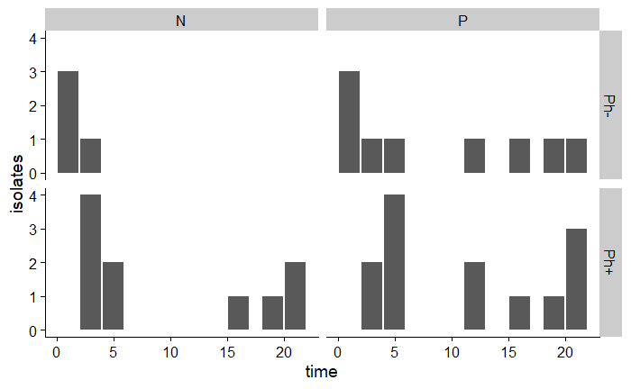

```r
d%>%
      filter(trt!="A")%>% #remove ancestor
       group_by(trt,lim,time) %>%
   summarize(isolates = n()) %>%
      ggplot(.,aes(x=time, y=isolates))+
      geom_bar(stat = "identity")+
      facet_grid(trt~lim)+
      theme_cowplot()
```

```r
d%>%
      filter(trt!="A")%>% #remove ancestor
       group_by(trt,lim) %>%
   summarize(isolates = n())
```

| trt | lim | isolates |
| --- | --- | --- |
| Ph- | N | 4 |
| Ph- | P | 9 |
| Ph+ | N | 10 |
| Ph+ | P | 13 |

```r
NA
```

So there are isolates from both phage and nom phage chemostats. For N-limitation, no-phage isolates are only from firat few days.

#Breseq  
First chunck of table

```r
d <- read.csv("../data/breseq.compare.csv", header = TRUE)
head(d,n=11)
```

|  | Predicted.mutations | X | X.1 | X.2 | X.3 | X.4 | X.5 | X.6 | X.7 | X.8 | X.9 | X.10 | X.11 | X.12 | X.13 | X.14 | X.15 | X.16 | X.17 | X.18 | X.19 | X.20 | X.21 | X.22 | X.23 | X.24 | X.25 | X.26 | X.27 | … |
| --- | --- | --- | --- | --- | --- | --- | --- | --- | --- | --- | --- | --- | --- | --- | --- | --- | --- | --- | --- | --- | --- | --- | --- | --- | --- | --- | --- | --- | --- | --- |
| 1 | position | mutation | 01N2S3.g | 01N3S3.g | 01N5S4.g | 01P3S1.g | 01P4S5.g | 01P5S1.g | 03N1S1.g | 03N2S5.g | 03N3S2.g | 03N3S4.g | 03N5S2.g | 03P2S4.g | 03P3S5.g | 03P5S5.g | 05N2S5.g | 05N3S3.g | 05P2S1.g | 05P2S2.g | 05P3S1.g | 05P4S4.g | 05P5S4.g | 12P2S5.g | 12P3S4.g | 12P4S2.g | 16N5S4.g | 16P3S2.g | 16P5S2.g | … |
| 2 | 1 | ?2,366,975 bp |  |  |  |  |  |  | 100% |  |  |  |  |  |  |  |  |  |  |  |  |  |  |  |  |  |  |  |  | … |
| 3 | 12,864 | C?G |  |  |  |  |  |  |  |  |  |  |  |  |  |  |  |  |  |  |  |  |  |  |  |  |  |  |  | … |
| 4 | 101,693 | C?T |  |  |  |  |  |  |  |  |  |  |  |  |  |  |  |  |  |  |  |  |  |  |  |  |  |  |  | … |
| 5 | 102,841 | G?A |  |  |  |  |  |  |  |  |  |  |  |  |  |  |  |  |  |  |  |  |  |  |  |  | 100% |  |  | … |
| 6 | 102,850 | C?T |  |  |  |  |  |  |  |  |  |  |  |  |  |  |  |  |  |  |  | 100% |  |  |  |  |  |  |  | … |
| 7 | 103,283 | C?A |  |  |  |  |  |  |  |  |  |  |  |  |  | 100% |  | 100% |  |  |  |  |  |  | 100% |  |  |  |  | … |
| 8 | 103,376 | C?T |  |  |  |  |  |  |  |  |  |  |  |  |  |  |  |  |  |  |  |  |  |  |  |  |  |  |  | … |
| 9 | 103,845 | A?T |  |  |  |  |  |  |  |  |  |  |  |  |  |  |  |  |  |  |  |  |  |  |  |  |  |  |  | … |
| 10 | 103,909 | G?A |  |  |  |  |  |  |  |  |  |  |  |  |  |  |  |  |  |  |  |  |  |  |  |  |  |  |  | … |

[output cut: 1 more lines]

Looking at the code organizing the mutation data in MLs .Rmd file. The data is processed to have a positionXstrain matrix. at one point this code chunk appears

```r
# Remove rows with no predicted mutations
class(breseq) = "numeric"
breseq <- breseq[-c(which(rowSums(breseq)==35)),]
```

At this point the table is 36 strains X 209 loci. I am not sure why the 35 cutoff was used. There are no rows with 36 mutaations, but there are rows with 34. there are 3 rows in whic 35/36 strains have mutations. In all 3 cases the same strainsoes not have this mutation, That strain is 03N1S1 (day 3, N-limited, chemostat 1, no-phage). Looking at the breseq file it seems this strain does not have any mutations. So in fact, the N-limited no phage chemostats have only day1 isolates. However this strain has not been removed from the next step of analysis.

Looing at the data partitioning into the +/- phage treatment, I think there is a problem. In this next chunk filtering is by a test applied to subset of table (`breseq.minus[,6:117]`) and applied to full table (`breseq.minus`).

I am also not sure why the columns `118:211` are ignored.

```r
load(file = "breseq.all.Rdata")

breseq.minus <- breseq.all[breseq.all$trt=="Ph-",]
breseq.minus <- breseq.minus[,-c(which(colSums(breseq.minus[,6:117]) ==0))]
breseq.minus.muts = colnames(breseq.minus[3:41])
breseq.plus <- breseq.all[breseq.all$trt=="Ph+",]
breseq.plus <- breseq.plus[,-c(which(colSums(breseq.plus[,6:117]) ==0))]
breseq.plus.muts = colnames(breseq.plus[5:89])

both <- intersect(breseq.minus.muts,breseq.plus.muts)
phage.minus.only <- setdiff(breseq.minus.muts,breseq.plus.muts)
phage.plus.only <- setdiff(breseq.plus.muts,breseq.minus.muts)
```

I will subset it my way and compare

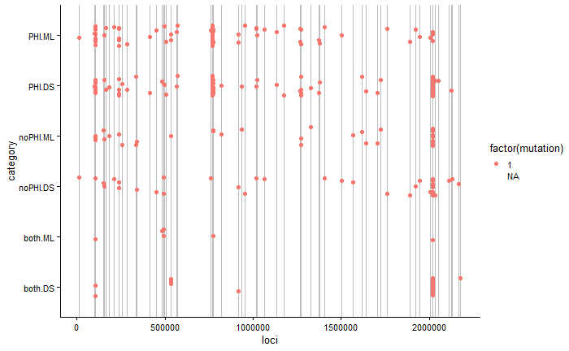

```r
sums <-
breseq.all%>%
      filter(trt=="Ph-")%>%
      select(6:ncol(breseq.all))%>%
      colSums()

breseq.minus2 <- breseq.all%>%
      filter(trt=="Ph-")%>%
      select(as.numeric(which(sums!=0)+5))

sums <-
breseq.all%>%
      filter(trt=="Ph+")%>%
      select(6:ncol(breseq.all))%>%
      colSums()

breseq.plus2 <- breseq.all%>%
      filter(trt=="Ph+")%>%
      select(as.numeric(which(sums!=0)+5))


breseq.minus.muts2 = colnames(breseq.minus2)
breseq.plus.muts2 = colnames(breseq.plus2)

both2 <- intersect(breseq.minus.muts2,breseq.plus.muts2)
phage.minus.only2 <- setdiff(breseq.minus.muts2,breseq.plus.muts2)
phage.plus.only2 <- setdiff(breseq.plus.muts2,breseq.minus.muts2)

all.muts <- breseq.all%>%
     select(6:ncol(breseq.all))%>%
     colnames()

df <- data.frame(loci=as.numeric(gsub(",", "",all.muts)))
df$both.ML <- ifelse(all.muts%in%both,1,NA)
df$both.DS <- ifelse(all.muts%in%both2,1,NA)
df$noPHI.ML <- ifelse(all.muts%in%phage.minus.only,1,NA)
df$noPHI.DS <- ifelse(all.muts%in%phage.minus.only2,1,NA)
df$PHI.ML <- ifelse(all.muts%in%phage.plus.only,1,NA)
df$PHI.DS <- ifelse(all.muts%in%phage.plus.only2,1,NA)


df%>%
      gather(key=category,value = mutation, 2:7)%>%
      ggplot(aes(x=loci, y=category))+
      geom_vline(xintercept = df$loci, color="grey")+
      geom_jitter(aes(color=factor(mutation)), width=0, height=0.2)+
      theme_cowplot(font_size = 10)+
      scale_color_discrete(na.value = NA)
```

```r
NA
```

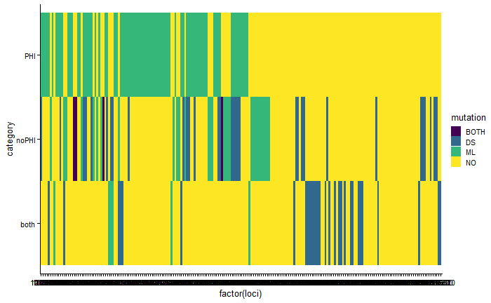

```r
df2 <- data.frame(loci = df$loci, both=NA, noPHI=NA, PHI=NA)
df2$both <- ifelse(is.na(df$both.ML), "NO","ML")
df2$both[!is.na(df$both.DS)] <- ifelse(df2$both[!is.na(df$both.DS)]=='ML', "BOTH", "DS")
df2$noPHI <- ifelse(is.na(df$noPHI.ML),"NO", "ML")
df2$noPHI[!is.na(df$noPHI.DS)] <- ifelse(df2$noPHI[!is.na(df$noPHI.DS)]=='ML', "BOTH", "DS")
df2$PHI <- ifelse(is.na(df$PHI.ML),"NO", "ML")
df2$PHI[!is.na(df$phi.DS)] <- ifelse(df2$PHI[!is.na(df$PHI.DS)]=='ML', "BOTH", "DS")

p <-
df2%>%
      gather(key=category,value = mutation, 2:4)%>%
      ggplot(aes(x=category, y=factor(loci)))+
      geom_tile(aes(fill=mutation))+
      theme_cowplot(font_size = 10)+
      scale_fill_viridis(discrete=TRUE)+
      coord_flip()
p
      ggsave2(p,filename = "loci.compared.jpg")
```

Tabulating the data I want to make a table of the genes in which mutations were found only in phage-treatment.

```r
# breseq <- as.data.frame(breseq)
breseq$loci <- loci
```

```
Coercing LHS to a list
```